# Ford GoBike System Data

## by Manal Alzeer

## Investigation Overview

Using a dataset of individual trips made in a bike-sharing system that covers the Greater San Francisco Bay Area in 2017, we sought to figure out the stations provided the most rides in San Francisco and where to take trips in terms of time, how long they took and if it varies If the recipient is a subscriber or a consumer.

## Dataset Overview

There are 519700 individual rides made in a bike-sharing system that covers the Greater San Francisco Bay Area,the most important features:

- Trip Duration (seconds)
- Start Time and Date
- End Time and Date
- Start Station Name
- End Station Name
- User Type (Subscriber or Customer – “Subscriber” = Member or “Customer” = Casual)

## The higher Users trips

Ford GoBike System currently offers two type : Subscriber or Customer

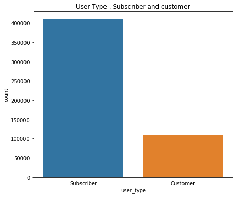

```python
order = df.user_type.value_counts().index
sb.countplot(data = df, x = 'user_type' , order = order)
plt.title('User Type : Subscriber and customer')
plt.gcf().set_size_inches(7, 6);
```

## The Most Start Stations Against User type

Which stations are the most used by both customers and subscribers

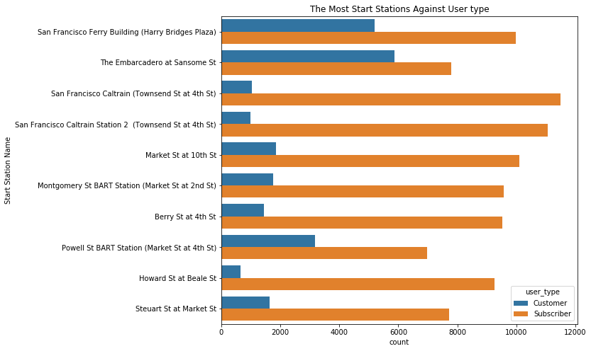

```python
order = df.start_station_name.value_counts()[:10].index
sb.countplot(data = df, y = 'start_station_name', hue = 'user_type', order = order)
plt.gcf().set_size_inches(9, 8)
plt.title('The Most Start Stations Against User type')
plt.ylabel('Start Station Name');
```

## Trip Duration Based Months And User type

The duration of the trips for both subscribers and customer per minutes for each month

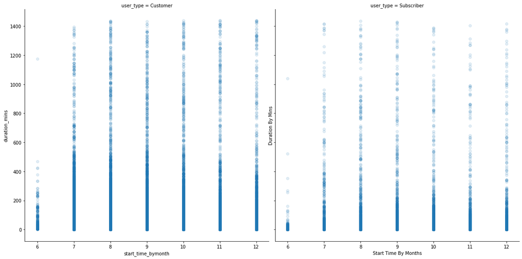

```python
g = sb.FacetGrid(data = df, col = 'user_type', col_wrap = 2, size = 8)
g.map(plt.scatter, 'start_time_bymonth', 'duration_mins', alpha= 1/8)
plt.xlabel('Start Time By Months')
plt.ylabel('Duration By Mins');
```

## The Most Start Stations based Months And User type

showing each of the customers, subscribers, and the 10 most trips stations during all months

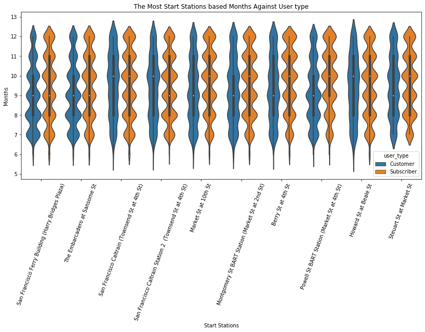

```python
order = df.start_station_name.value_counts()[:10].index
sb.violinplot(data = df,y='start_time_bymonth' ,x = 'start_station_name', hue = 'user_type', order = order)
plt.gcf().set_size_inches(14, 6)
plt.xticks(rotation = 70)
plt.title('The Most Start Stations based Months Against User type')
plt.xlabel('Start Stations')
plt.ylabel('Months');
```

```python
!jupyter nbconvert explanatory.ipynb --to slides --post serve --template output_toggle
```